# Project: Wrangling and Analyze Data

## Data Gathering

In the cell below, gather **all** three pieces of data for this project and load them in the notebook. **Note:** the methods required to gather each data are different.

1. Directly download the WeRateDogs Twitter archive data (twitter_archive_enhanced.csv)

```python
pip install tweepy
```

```python
import pandas as pd
import numpy as np
import requests
import json
import tweepy
import io
import matplotlib.pyplot as plt
import seaborn as sns
from urllib.request import urlopen
from PIL import Image
%matplotlib inline
```

```python
twitter_archive_enhanced = pd.read_csv('twitter-archive-enhanced.csv')
```

```python
twitter_archive_enhanced.head()
```

|  | tweet_id | in_reply_to_status_id | in_reply_to_user_id | timestamp | source | text | retweeted_status_id | retweeted_status_user_id | retweeted_status_timestamp | expanded_urls | rating_numerator | rating_denominator | name | doggo | floofer | pupper | puppo |
| --- | --- | --- | --- | --- | --- | --- | --- | --- | --- | --- | --- | --- | --- | --- | --- | --- | --- |
| 0 | 892420643555336193 | NaN | NaN | 2017-08-01 16:23:56 +0000 | <a href="http://twitter.com/download/iphone" r... | This is Phineas. He's a mystical boy. Only eve... | NaN | NaN | NaN | https://twitter.com/dog_rates/status/892420643... | 13 | 10 | Phineas | None | None | None | None |
| 1 | 892177421306343426 | NaN | NaN | 2017-08-01 00:17:27 +0000 | <a href="http://twitter.com/download/iphone" r... | This is Tilly. She's just checking pup on you.... | NaN | NaN | NaN | https://twitter.com/dog_rates/status/892177421... | 13 | 10 | Tilly | None | None | None | None |
| 2 | 891815181378084864 | NaN | NaN | 2017-07-31 00:18:03 +0000 | <a href="http://twitter.com/download/iphone" r... | This is Archie. He is a rare Norwegian Pouncin... | NaN | NaN | NaN | https://twitter.com/dog_rates/status/891815181... | 12 | 10 | Archie | None | None | None | None |
| 3 | 891689557279858688 | NaN | NaN | 2017-07-30 15:58:51 +0000 | <a href="http://twitter.com/download/iphone" r... | This is Darla. She commenced a snooze mid meal... | NaN | NaN | NaN | https://twitter.com/dog_rates/status/891689557... | 13 | 10 | Darla | None | None | None | None |
| 4 | 891327558926688256 | NaN | NaN | 2017-07-29 16:00:24 +0000 | <a href="http://twitter.com/download/iphone" r... | This is Franklin. He would like you to stop ca... | NaN | NaN | NaN | https://twitter.com/dog_rates/status/891327558... | 12 | 10 | Franklin | None | None | None | None |

1. Use the Requests library to download the tweet image prediction (image_predictions.tsv)

```python
url = 'https://d17h27t6h515a5.cloudfront.net/topher/2017/August/599fd2ad_image-predictions/image-predictions.tsv'
r = requests.get('https://d17h27t6h515a5.cloudfront.net/topher/2017/August/599fd2ad_image-predictions/image-predictions.tsv')
image_pred = pd.read_csv(io.StringIO(r.text), sep='\t')
```

```python
image_pred.info()
```

```
<class 'pandas.core.frame.DataFrame'>
RangeIndex: 2075 entries, 0 to 2074
Data columns (total 12 columns):
 #   Column    Non-Null Count  Dtype
---  ------    --------------  -----
 0   tweet_id  2075 non-null   int64
 1   jpg_url   2075 non-null   object
 2   img_num   2075 non-null   int64
 3   p1        2075 non-null   object
 4   p1_conf   2075 non-null   float64
 5   p1_dog    2075 non-null   bool
 6   p2        2075 non-null   object
 7   p2_conf   2075 non-null   float64
 8   p2_dog    2075 non-null   bool
 9   p3        2075 non-null   object
 10  p3_conf   2075 non-null   float64
 11  p3_dog    2075 non-null   bool
dtypes: bool(3), float64(3), int64(2), object(4)
memory usage: 152.1+ KB
```

```python
image_pred.head()
```

|  | tweet_id | jpg_url | img_num | p1 | p1_conf | p1_dog | p2 | p2_conf | p2_dog | p3 | p3_conf | p3_dog |
| --- | --- | --- | --- | --- | --- | --- | --- | --- | --- | --- | --- | --- |
| 0 | 666020888022790149 | https://pbs.twimg.com/media/CT4udn0WwAA0aMy.jpg | 1 | Welsh_springer_spaniel | 0.465074 | True | collie | 0.156665 | True | Shetland_sheepdog | 0.061428 | True |
| 1 | 666029285002620928 | https://pbs.twimg.com/media/CT42GRgUYAA5iDo.jpg | 1 | redbone | 0.506826 | True | miniature_pinscher | 0.074192 | True | Rhodesian_ridgeback | 0.072010 | True |
| 2 | 666033412701032449 | https://pbs.twimg.com/media/CT4521TWwAEvMyu.jpg | 1 | German_shepherd | 0.596461 | True | malinois | 0.138584 | True | bloodhound | 0.116197 | True |
| 3 | 666044226329800704 | https://pbs.twimg.com/media/CT5Dr8HUEAA-lEu.jpg | 1 | Rhodesian_ridgeback | 0.408143 | True | redbone | 0.360687 | True | miniature_pinscher | 0.222752 | True |
| 4 | 666049248165822465 | https://pbs.twimg.com/media/CT5IQmsXIAAKY4A.jpg | 1 | miniature_pinscher | 0.560311 | True | Rottweiler | 0.243682 | True | Doberman | 0.154629 | True |

1. Use the Tweepy library to query additional data via the Twitter API (tweet_json.txt)

```python
consumer_key = ''
consumer_secret = ''
access_token = ''
access_secret = ''

auth = tweepy.OAuthHandler(consumer_key, consumer_secret)
auth.set_access_token(access_token, access_secret)

api = tweepy.API(auth)
```

```python
# create list of tweet_ids
tweet_ids = list(image_pred.tweet_id.copy())
```

```python
# create list for tweet json data
tweet_json = []

# iterate through tweet ids to retrieve tweets as json objects:
for tweet in tweet_ids:
    # use try/except for missing tweet ids
    try:
        tweet = api.get_status(tweet)
        tweet_json.append(tweet._json)
    except:
        continue
```

```python
with open ('tweet_json.txt', 'w') as file:
    json.dump(tweet_json, file)
```

```python
with open ('tweet_json.txt') as json_file:
    tweets = json.load(json_file)
```

```python
tweets = pd.DataFrame(tweets)
```

```python
tweets.head()
```

|  | created_at | id | id_str | text | truncated | entities | extended_entities | source | in_reply_to_status_id | in_reply_to_status_id_str | ... | contributors | is_quote_status | retweet_count | favorite_count | favorited | retweeted | possibly_sensitive | possibly_sensitive_appealable | lang | retweeted_status |
| --- | --- | --- | --- | --- | --- | --- | --- | --- | --- | --- | --- | --- | --- | --- | --- | --- | --- | --- | --- | --- | --- |
| 0 | Sun Nov 15 22:32:08 +0000 2015 | 666020888022790149 | 666020888022790149 | Here we have a Japanese Irish Setter. Lost eye... | False | {'hashtags': [], 'symbols': [], 'user_mentions... | {'media': [{'id': 666020881337073664, 'id_str'... | <a href="http://twitter.com/download/iphone" r... | NaN | None | ... | None | False | 426 | 2310 | False | False | False | False | en | NaN |
| 1 | Sun Nov 15 23:05:30 +0000 2015 | 666029285002620928 | 666029285002620928 | This is a western brown Mitsubishi terrier. Up... | False | {'hashtags': [], 'symbols': [], 'user_mentions... | {'media': [{'id': 666029276303482880, 'id_str'... | <a href="http://twitter.com/download/iphone" r... | NaN | None | ... | None | False | 39 | 114 | False | False | False | False | en | NaN |
| 2 | Sun Nov 15 23:21:54 +0000 2015 | 666033412701032449 | 666033412701032449 | Here is a very happy pup. Big fan of well-main... | False | {'hashtags': [], 'symbols': [], 'user_mentions... | {'media': [{'id': 666033409081393153, 'id_str'... | <a href="http://twitter.com/download/iphone" r... | NaN | None | ... | None | False | 36 | 100 | False | False | False | False | en | NaN |
| 3 | Mon Nov 16 00:04:52 +0000 2015 | 666044226329800704 | 666044226329800704 | This is a purebred Piers Morgan. Loves to Netf... | False | {'hashtags': [], 'symbols': [], 'user_mentions... | {'media': [{'id': 666044217047650304, 'id_str'... | <a href="http://twitter.com/download/iphone" r... | NaN | None | ... | None | False | 117 | 248 | False | False | False | False | en | NaN |
| 4 | Mon Nov 16 00:24:50 +0000 2015 | 666049248165822465 | 666049248165822465 | Here we have a 1949 1st generation vulpix. Enj... | False | {'hashtags': [], 'symbols': [], 'user_mentions... | {'media': [{'id': 666049244999131136, 'id_str'... | <a href="http://twitter.com/download/iphone" r... | NaN | None | ... | None | False | 37 | 89 | False | False | False | False | en | NaN |

5 rows × 27 columns

## Assessing Data

In this section, detect and document at least **eight (8) quality issues and two (2) tidiness issue**. You must use **both** visual assessment programmatic assessement to assess the data.

**Note:** pay attention to the following key points when you access the data.

- You only want original ratings (no retweets) that have images. Though there are 5000+ tweets in the dataset, not all are dog ratings and some are retweets.
- Assessing and cleaning the entire dataset completely would require a lot of time, and is not necessary to practice and demonstrate your skills in data wrangling. Therefore, the requirements of this project are only to assess and clean at least 8 quality issues and at least 2 tidiness issues in this dataset.
- The fact that the rating numerators are greater than the denominators does not need to be cleaned. This [unique rating system](http://knowyourmeme.com/memes/theyre-good-dogs-brent) is a big part of the popularity of WeRateDogs.
- You do not need to gather the tweets beyond August 1st, 2017. You can, but note that you won't be able to gather the image predictions for these tweets since you don't have access to the algorithm used.

```python
# visually inspect twitter_archive_enhanced
twitter_archive_enhanced.head()
```

|  | tweet_id | in_reply_to_status_id | in_reply_to_user_id | timestamp | source | text | retweeted_status_id | retweeted_status_user_id | retweeted_status_timestamp | expanded_urls | rating_numerator | rating_denominator | name | doggo | floofer | pupper | puppo |
| --- | --- | --- | --- | --- | --- | --- | --- | --- | --- | --- | --- | --- | --- | --- | --- | --- | --- |
| 0 | 892420643555336193 | NaN | NaN | 2017-08-01 16:23:56 +0000 | <a href="http://twitter.com/download/iphone" r... | This is Phineas. He's a mystical boy. Only eve... | NaN | NaN | NaN | https://twitter.com/dog_rates/status/892420643... | 13 | 10 | Phineas | None | None | None | None |
| 1 | 892177421306343426 | NaN | NaN | 2017-08-01 00:17:27 +0000 | <a href="http://twitter.com/download/iphone" r... | This is Tilly. She's just checking pup on you.... | NaN | NaN | NaN | https://twitter.com/dog_rates/status/892177421... | 13 | 10 | Tilly | None | None | None | None |
| 2 | 891815181378084864 | NaN | NaN | 2017-07-31 00:18:03 +0000 | <a href="http://twitter.com/download/iphone" r... | This is Archie. He is a rare Norwegian Pouncin... | NaN | NaN | NaN | https://twitter.com/dog_rates/status/891815181... | 12 | 10 | Archie | None | None | None | None |
| 3 | 891689557279858688 | NaN | NaN | 2017-07-30 15:58:51 +0000 | <a href="http://twitter.com/download/iphone" r... | This is Darla. She commenced a snooze mid meal... | NaN | NaN | NaN | https://twitter.com/dog_rates/status/891689557... | 13 | 10 | Darla | None | None | None | None |
| 4 | 891327558926688256 | NaN | NaN | 2017-07-29 16:00:24 +0000 | <a href="http://twitter.com/download/iphone" r... | This is Franklin. He would like you to stop ca... | NaN | NaN | NaN | https://twitter.com/dog_rates/status/891327558... | 12 | 10 | Franklin | None | None | None | None |

```python
twitter_archive_enhanced.sample(25)
```

|  | tweet_id | in_reply_to_status_id | in_reply_to_user_id | timestamp | source | text | retweeted_status_id | retweeted_status_user_id | retweeted_status_timestamp | expanded_urls | rating_numerator | rating_denominator | name | doggo | floofer | pupper | puppo |
| --- | --- | --- | --- | --- | --- | --- | --- | --- | --- | --- | --- | --- | --- | --- | --- | --- | --- |
| 1690 | 681339448655802368 | NaN | NaN | 2015-12-28 05:02:37 +0000 | <a href="http://twitter.com/download/iphone" r... | This is Asher. He's not wearing a seatbelt or ... | NaN | NaN | NaN | https://twitter.com/dog_rates/status/681339448... | 9 | 10 | Asher | None | None | None | None |
| 1590 | 686618349602762752 | NaN | NaN | 2016-01-11 18:39:05 +0000 | <a href="http://twitter.com/download/iphone" r... | This is Olivia. She just saw an adult wearing ... | NaN | NaN | NaN | https://twitter.com/dog_rates/status/686618349... | 11 | 10 | Olivia | None | None | pupper | None |
| 1042 | 743895849529389061 | NaN | NaN | 2016-06-17 19:59:26 +0000 | <a href="http://twitter.com/download/iphone" r... | When you're given AUX cord privileges from the... | NaN | NaN | NaN | https://twitter.com/dog_rates/status/743895849... | 10 | 10 | None | None | None | None | None |
| 678 | 789268448748703744 | NaN | NaN | 2016-10-21 00:53:56 +0000 | <a href="http://twitter.com/download/iphone" r... | This is Stella. She's happier than I will ever... | NaN | NaN | NaN | https://twitter.com/dog_rates/status/789268448... | 10 | 10 | Stella | None | None | None | None |
| 154 | 862096992088072192 | NaN | NaN | 2017-05-10 00:08:34 +0000 | <a href="http://twitter.com/download/iphone" r... | We only rate dogs. Please don't send perfectly... | NaN | NaN | NaN | https://twitter.com/dog_rates/status/862096992... | 13 | 10 | None | None | None | None | None |
| 138 | 865718153858494464 | NaN | NaN | 2017-05-19 23:57:46 +0000 | <a href="http://twitter.com/download/iphone" r... | Meet Boomer. He's just checking pup on you. Ho... | NaN | NaN | NaN | https://twitter.com/dog_rates/status/865718153... | 13 | 10 | Boomer | None | None | None | None |
| 1557 | 688804835492233216 | NaN | NaN | 2016-01-17 19:27:24 +0000 | <a href="http://twitter.com/download/iphone" r... | When you stumble but recover quickly cause you... | NaN | NaN | NaN | https://twitter.com/dog_rates/status/688804835... | 12 | 10 | None | None | None | None | None |
| 1432 | 697482927769255936 | NaN | NaN | 2016-02-10 18:11:03 +0000 | <a href="http://twitter.com/download/iphone" r... | Meet Blipson. He's a Doowap Hufflepuff. That U... | NaN | NaN | NaN | https://twitter.com/dog_rates/status/697482927... | 11 | 10 | Blipson | None | None | None | None |
| 1653 | 683462770029932544 | NaN | NaN | 2016-01-03 01:39:57 +0000 | <a href="http://twitter.com/download/iphone" r... | "Hello forest pupper I am house pupper welcome... | NaN | NaN | NaN | https://twitter.com/dog_rates/status/683462770... | 8 | 10 | None | None | None | pupper | None |
| 1401 | 699434518667751424 | NaN | NaN | 2016-02-16 03:25:58 +0000 | <a href="http://twitter.com/download/iphone" r... | I know this is a tad late but here's a wonderf... | NaN | NaN | NaN | https://twitter.com/dog_rates/status/699434518... | 12 | 10 | None | None | None | pupper | None |
| 1315 | 706681918348251136 | NaN | NaN | 2016-03-07 03:24:33 +0000 | <a href="http://twitter.com/download/iphone" r... | Say hello to Katie. She's a Mitsubishi Hufflep... | NaN | NaN | NaN | https://twitter.com/dog_rates/status/706681918... | 12 | 10 | Katie | None | None | None | None |
| 94 | 874012996292530176 | NaN | NaN | 2017-06-11 21:18:31 +0000 | <a href="http://twitter.com/download/iphone" r... | This is Sebastian. He can't see all the colors... | NaN | NaN | NaN | https://twitter.com/dog_rates/status/874012996... | 13 | 10 | Sebastian | None | None | None | puppo |
| 831 | 768609597686943744 | NaN | NaN | 2016-08-25 00:43:02 +0000 | <a href="http://twitter.com/download/iphone" r... | This is Lou. His sweater is too small and he a... | NaN | NaN | NaN | https://twitter.com/dog_rates/status/768609597... | 10 | 10 | Lou | None | None | None | None |
| 264 | 842163532590374912 | NaN | NaN | 2017-03-16 00:00:07 +0000 | <a href="http://twitter.com/download/iphone" r... | Meet George. He looks slightly deflated but ov... | NaN | NaN | NaN | https://twitter.com/dog_rates/status/842163532... | 12 | 10 | George | None | None | None | None |
| 475 | 816062466425819140 | NaN | NaN | 2017-01-02 23:23:48 +0000 | <a href="http://twitter.com/download/iphone" r... | RT @dog_rates: Meet Jack. He's one of the rare... | 8.159907e+17 | 4.196984e+09 | 2017-01-02 18:38:42 +0000 | https://www.gofundme.com/surgeryforjacktheminp... | 11 | 10 | Jack | None | None | None | None |
| 1358 | 703382836347330562 | NaN | NaN | 2016-02-27 00:55:11 +0000 | <a href="http://twitter.com/download/iphone" r... | This is Charlie. He's a West Side Niddlewog. M... | NaN | NaN | NaN | https://twitter.com/dog_rates/status/703382836... | 12 | 10 | Charlie | None | None | None | None |
| 240 | 846514051647705089 | NaN | NaN | 2017-03-28 00:07:32 +0000 | <a href="http://twitter.com/download/iphone" r... | This is Barney. He's an elder doggo. Hitches a... | NaN | NaN | NaN | https://twitter.com/dog_rates/status/846514051... | 13 | 10 | Barney | doggo | None | None | None |
| 1536 | 689905486972461056 | NaN | NaN | 2016-01-20 20:21:00 +0000 | <a href="http://twitter.com/download/iphone" r... | Say hello to Gizmo. He's quite the pupper. Con... | NaN | NaN | NaN | https://twitter.com/dog_rates/status/689905486... | 11 | 10 | Gizmo | None | None | pupper | None |
| 1262 | 710140971284037632 | NaN | NaN | 2016-03-16 16:29:35 +0000 | <a href="http://twitter.com/download/iphone" r... | This is Tater. His underbite is fierce af. Doe... | NaN | NaN | NaN | https://twitter.com/dog_rates/status/710140971... | 8 | 10 | Tater | None | None | None | None |
| 2176 | 669203728096960512 | NaN | NaN | 2015-11-24 17:19:36 +0000 | <a href="http://twitter.com/download/iphone" r... | This is Samsom. He is sexually confused. Reall... | NaN | NaN | NaN | https://twitter.com/dog_rates/status/669203728... | 9 | 10 | Samsom | None | None | None | None |
| 2053 | 671485057807351808 | NaN | NaN | 2015-12-01 00:24:48 +0000 | <a href="http://twitter.com/download/iphone" r... | Meet Penelope. She is a white Macadamias Duode... | NaN | NaN | NaN | https://twitter.com/dog_rates/status/671485057... | 11 | 10 | Penelope | None | None | None | None |
| 2276 | 667443425659232256 | NaN | NaN | 2015-11-19 20:44:47 +0000 | <a href="http://twitter.com/download/iphone" r... | Exotic dog here. Long neck. Weird paws. Obsess... | NaN | NaN | NaN | https://twitter.com/dog_rates/status/667443425... | 6 | 10 | None | None | None | None | None |
| 360 | 829861396166877184 | NaN | NaN | 2017-02-10 01:15:49 +0000 | <a href="http://twitter.com/download/iphone" r... | This is Mia. She already knows she's a good do... | NaN | NaN | NaN | https://twitter.com/dog_rates/status/829861396... | 12 | 10 | Mia | None | None | None | None |
| 1159 | 724046343203856385 | NaN | NaN | 2016-04-24 01:24:35 +0000 | <a href="http://twitter.com/download/iphone" r... | This is Sarge. Not even he knows what his tong... | NaN | NaN | NaN | https://twitter.com/dog_rates/status/724046343... | 10 | 10 | Sarge | None | None | None | None |
| 876 | 761004547850530816 | NaN | NaN | 2016-08-04 01:03:17 +0000 | <a href="http://twitter.com/download/iphone" r... | This is Bo and Ty. Bo eats paper and Ty felt l... | NaN | NaN | NaN | https://twitter.com/dog_rates/status/761004547... | 11 | 10 | Bo | None | None | None | None |

```python
twitter_archive_enhanced.head(10)
```

|  | tweet_id | in_reply_to_status_id | in_reply_to_user_id | timestamp | source | text | retweeted_status_id | retweeted_status_user_id | retweeted_status_timestamp | expanded_urls | rating_numerator | rating_denominator | name | doggo | floofer | pupper | puppo |
| --- | --- | --- | --- | --- | --- | --- | --- | --- | --- | --- | --- | --- | --- | --- | --- | --- | --- |
| 0 | 892420643555336193 | NaN | NaN | 2017-08-01 16:23:56 +0000 | <a href="http://twitter.com/download/iphone" r... | This is Phineas. He's a mystical boy. Only eve... | NaN | NaN | NaN | https://twitter.com/dog_rates/status/892420643... | 13 | 10 | Phineas | None | None | None | None |
| 1 | 892177421306343426 | NaN | NaN | 2017-08-01 00:17:27 +0000 | <a href="http://twitter.com/download/iphone" r... | This is Tilly. She's just checking pup on you.... | NaN | NaN | NaN | https://twitter.com/dog_rates/status/892177421... | 13 | 10 | Tilly | None | None | None | None |
| 2 | 891815181378084864 | NaN | NaN | 2017-07-31 00:18:03 +0000 | <a href="http://twitter.com/download/iphone" r... | This is Archie. He is a rare Norwegian Pouncin... | NaN | NaN | NaN | https://twitter.com/dog_rates/status/891815181... | 12 | 10 | Archie | None | None | None | None |
| 3 | 891689557279858688 | NaN | NaN | 2017-07-30 15:58:51 +0000 | <a href="http://twitter.com/download/iphone" r... | This is Darla. She commenced a snooze mid meal... | NaN | NaN | NaN | https://twitter.com/dog_rates/status/891689557... | 13 | 10 | Darla | None | None | None | None |
| 4 | 891327558926688256 | NaN | NaN | 2017-07-29 16:00:24 +0000 | <a href="http://twitter.com/download/iphone" r... | This is Franklin. He would like you to stop ca... | NaN | NaN | NaN | https://twitter.com/dog_rates/status/891327558... | 12 | 10 | Franklin | None | None | None | None |
| 5 | 891087950875897856 | NaN | NaN | 2017-07-29 00:08:17 +0000 | <a href="http://twitter.com/download/iphone" r... | Here we have a majestic great white breaching ... | NaN | NaN | NaN | https://twitter.com/dog_rates/status/891087950... | 13 | 10 | None | None | None | None | None |
| 6 | 890971913173991426 | NaN | NaN | 2017-07-28 16:27:12 +0000 | <a href="http://twitter.com/download/iphone" r... | Meet Jax. He enjoys ice cream so much he gets ... | NaN | NaN | NaN | https://gofundme.com/ydvmve-surgery-for-jax,ht... | 13 | 10 | Jax | None | None | None | None |
| 7 | 890729181411237888 | NaN | NaN | 2017-07-28 00:22:40 +0000 | <a href="http://twitter.com/download/iphone" r... | When you watch your owner call another dog a g... | NaN | NaN | NaN | https://twitter.com/dog_rates/status/890729181... | 13 | 10 | None | None | None | None | None |
| 8 | 890609185150312448 | NaN | NaN | 2017-07-27 16:25:51 +0000 | <a href="http://twitter.com/download/iphone" r... | This is Zoey. She doesn't want to be one of th... | NaN | NaN | NaN | https://twitter.com/dog_rates/status/890609185... | 13 | 10 | Zoey | None | None | None | None |
| 9 | 890240255349198849 | NaN | NaN | 2017-07-26 15:59:51 +0000 | <a href="http://twitter.com/download/iphone" r... | This is Cassie. She is a college pup. Studying... | NaN | NaN | NaN | https://twitter.com/dog_rates/status/890240255... | 14 | 10 | Cassie | doggo | None | None | None |

```python
twitter_archive_enhanced.tail(10)
```

|  | tweet_id | in_reply_to_status_id | in_reply_to_user_id | timestamp | source | text | retweeted_status_id | retweeted_status_user_id | retweeted_status_timestamp | expanded_urls | rating_numerator | rating_denominator | name | doggo | floofer | pupper | puppo |
| --- | --- | --- | --- | --- | --- | --- | --- | --- | --- | --- | --- | --- | --- | --- | --- | --- | --- |
| 2346 | 666058600524156928 | NaN | NaN | 2015-11-16 01:01:59 +0000 | <a href="http://twitter.com/download/iphone" r... | Here is the Rand Paul of retrievers folks! He'... | NaN | NaN | NaN | https://twitter.com/dog_rates/status/666058600... | 8 | 10 | the | None | None | None | None |
| 2347 | 666057090499244032 | NaN | NaN | 2015-11-16 00:55:59 +0000 | <a href="http://twitter.com/download/iphone" r... | My oh my. This is a rare blond Canadian terrie... | NaN | NaN | NaN | https://twitter.com/dog_rates/status/666057090... | 9 | 10 | a | None | None | None | None |
| 2348 | 666055525042405380 | NaN | NaN | 2015-11-16 00:49:46 +0000 | <a href="http://twitter.com/download/iphone" r... | Here is a Siberian heavily armored polar bear ... | NaN | NaN | NaN | https://twitter.com/dog_rates/status/666055525... | 10 | 10 | a | None | None | None | None |
| 2349 | 666051853826850816 | NaN | NaN | 2015-11-16 00:35:11 +0000 | <a href="http://twitter.com/download/iphone" r... | This is an odd dog. Hard on the outside but lo... | NaN | NaN | NaN | https://twitter.com/dog_rates/status/666051853... | 2 | 10 | an | None | None | None | None |
| 2350 | 666050758794694657 | NaN | NaN | 2015-11-16 00:30:50 +0000 | <a href="http://twitter.com/download/iphone" r... | This is a truly beautiful English Wilson Staff... | NaN | NaN | NaN | https://twitter.com/dog_rates/status/666050758... | 10 | 10 | a | None | None | None | None |
| 2351 | 666049248165822465 | NaN | NaN | 2015-11-16 00:24:50 +0000 | <a href="http://twitter.com/download/iphone" r... | Here we have a 1949 1st generation vulpix. Enj... | NaN | NaN | NaN | https://twitter.com/dog_rates/status/666049248... | 5 | 10 | None | None | None | None | None |
| 2352 | 666044226329800704 | NaN | NaN | 2015-11-16 00:04:52 +0000 | <a href="http://twitter.com/download/iphone" r... | This is a purebred Piers Morgan. Loves to Netf... | NaN | NaN | NaN | https://twitter.com/dog_rates/status/666044226... | 6 | 10 | a | None | None | None | None |
| 2353 | 666033412701032449 | NaN | NaN | 2015-11-15 23:21:54 +0000 | <a href="http://twitter.com/download/iphone" r... | Here is a very happy pup. Big fan of well-main... | NaN | NaN | NaN | https://twitter.com/dog_rates/status/666033412... | 9 | 10 | a | None | None | None | None |
| 2354 | 666029285002620928 | NaN | NaN | 2015-11-15 23:05:30 +0000 | <a href="http://twitter.com/download/iphone" r... | This is a western brown Mitsubishi terrier. Up... | NaN | NaN | NaN | https://twitter.com/dog_rates/status/666029285... | 7 | 10 | a | None | None | None | None |
| 2355 | 666020888022790149 | NaN | NaN | 2015-11-15 22:32:08 +0000 | <a href="http://twitter.com/download/iphone" r... | Here we have a Japanese Irish Setter. Lost eye... | NaN | NaN | NaN | https://twitter.com/dog_rates/status/666020888... | 8 | 10 | None | None | None | None | None |

- It looks like there are a lot of columns with missing values.

```python
# visually inspect the image_pred dataset
image_pred
```

|  | tweet_id | jpg_url | img_num | p1 | p1_conf | p1_dog | p2 | p2_conf | p2_dog | p3 | p3_conf | p3_dog |
| --- | --- | --- | --- | --- | --- | --- | --- | --- | --- | --- | --- | --- |
| 0 | 666020888022790149 | https://pbs.twimg.com/media/CT4udn0WwAA0aMy.jpg | 1 | Welsh_springer_spaniel | 0.465074 | True | collie | 0.156665 | True | Shetland_sheepdog | 0.061428 | True |
| 1 | 666029285002620928 | https://pbs.twimg.com/media/CT42GRgUYAA5iDo.jpg | 1 | redbone | 0.506826 | True | miniature_pinscher | 0.074192 | True | Rhodesian_ridgeback | 0.072010 | True |
| 2 | 666033412701032449 | https://pbs.twimg.com/media/CT4521TWwAEvMyu.jpg | 1 | German_shepherd | 0.596461 | True | malinois | 0.138584 | True | bloodhound | 0.116197 | True |
| 3 | 666044226329800704 | https://pbs.twimg.com/media/CT5Dr8HUEAA-lEu.jpg | 1 | Rhodesian_ridgeback | 0.408143 | True | redbone | 0.360687 | True | miniature_pinscher | 0.222752 | True |
| 4 | 666049248165822465 | https://pbs.twimg.com/media/CT5IQmsXIAAKY4A.jpg | 1 | miniature_pinscher | 0.560311 | True | Rottweiler | 0.243682 | True | Doberman | 0.154629 | True |
| ... | ... | ... | ... | ... | ... | ... | ... | ... | ... | ... | ... | ... |
| 2070 | 891327558926688256 | https://pbs.twimg.com/media/DF6hr6BUMAAzZgT.jpg | 2 | basset | 0.555712 | True | English_springer | 0.225770 | True | German_short-haired_pointer | 0.175219 | True |
| 2071 | 891689557279858688 | https://pbs.twimg.com/media/DF_q7IAWsAEuuN8.jpg | 1 | paper_towel | 0.170278 | False | Labrador_retriever | 0.168086 | True | spatula | 0.040836 | False |
| 2072 | 891815181378084864 | https://pbs.twimg.com/media/DGBdLU1WsAANxJ9.jpg | 1 | Chihuahua | 0.716012 | True | malamute | 0.078253 | True | kelpie | 0.031379 | True |
| 2073 | 892177421306343426 | https://pbs.twimg.com/media/DGGmoV4XsAAUL6n.jpg | 1 | Chihuahua | 0.323581 | True | Pekinese | 0.090647 | True | papillon | 0.068957 | True |
| 2074 | 892420643555336193 | https://pbs.twimg.com/media/DGKD1-bXoAAIAUK.jpg | 1 | orange | 0.097049 | False | bagel | 0.085851 | False | banana | 0.076110 | False |

2075 rows × 12 columns

```python
image_pred.sample(25)
```

|  | tweet_id | jpg_url | img_num | p1 | p1_conf | p1_dog | p2 | p2_conf | p2_dog | p3 | p3_conf | p3_dog |
| --- | --- | --- | --- | --- | --- | --- | --- | --- | --- | --- | --- | --- |
| 1021 | 710269109699739648 | https://pbs.twimg.com/media/Cdth_KyWEAEXH3u.jpg | 1 | pug | 0.415495 | True | German_shepherd | 0.178157 | True | Labrador_retriever | 0.100202 | True |
| 242 | 670449342516494336 | https://pbs.twimg.com/media/CU3qHNTWsAApGr0.jpg | 1 | peacock | 0.999924 | False | European_gallinule | 0.000030 | False | agama | 0.000022 | False |
| 1385 | 766008592277377025 | https://pbs.twimg.com/media/CqFouXOXYAAYpzG.jpg | 1 | Welsh_springer_spaniel | 0.728153 | True | basset | 0.103842 | True | Brittany_spaniel | 0.062414 | True |
| 1438 | 774314403806253056 | https://pbs.twimg.com/media/Cr7q1VxWIAA5Nm7.jpg | 3 | Eskimo_dog | 0.596045 | True | Siberian_husky | 0.223067 | True | Saluki | 0.036325 | True |
| 1521 | 788039637453406209 | https://pbs.twimg.com/media/Cu-t20yWEAAFHXi.jpg | 1 | beach_wagon | 0.362925 | False | minivan | 0.304759 | False | limousine | 0.101702 | False |
| 1088 | 718971898235854848 | https://pbs.twimg.com/media/CfpNGTHUIAAA8XC.jpg | 1 | golden_retriever | 0.140394 | True | Saint_Bernard | 0.118769 | True | Labrador_retriever | 0.075492 | True |
| 1514 | 786664955043049472 | https://pbs.twimg.com/media/CurLmoqXgAEPoJ-.jpg | 1 | Leonberg | 0.512034 | True | keeshond | 0.464816 | True | Pomeranian | 0.007812 | True |
| 198 | 669625907762618368 | https://pbs.twimg.com/media/CUr9NjgU8AEpf5w.jpg | 1 | seat_belt | 0.874502 | False | golden_retriever | 0.055408 | True | Labrador_retriever | 0.026854 | True |
| 911 | 700796979434098688 | https://pbs.twimg.com/media/Cbm7IeUXIAA6Lc-.jpg | 1 | tailed_frog | 0.652712 | False | tree_frog | 0.280212 | False | bullfrog | 0.040177 | False |
| 1750 | 823939628516474880 | https://pbs.twimg.com/media/C284uD8WgAEmMVn.jpg | 1 | schipperke | 0.234076 | True | curly-coated_retriever | 0.193093 | True | Labrador_retriever | 0.095197 | True |
| 1259 | 748699167502000129 | https://pbs.twimg.com/media/CmPp5pOXgAAD_SG.jpg | 1 | Pembroke | 0.849029 | True | Cardigan | 0.083629 | True | kelpie | 0.024394 | True |
| 276 | 670840546554966016 | https://pbs.twimg.com/media/CU9N6upXAAAbtQe.jpg | 1 | Shih-Tzu | 0.963622 | True | Lhasa | 0.016017 | True | guinea_pig | 0.007932 | False |
| 1793 | 831262627380748289 | https://pbs.twimg.com/media/C4k88lGVMAEKNzb.jpg | 1 | cocker_spaniel | 0.263323 | True | Brittany_spaniel | 0.200550 | True | doormat | 0.193414 | False |
| 1784 | 829141528400556032 | https://pbs.twimg.com/media/C4GzztSWAAA_qi4.jpg | 2 | golden_retriever | 0.573140 | True | cocker_spaniel | 0.111159 | True | gibbon | 0.094127 | False |
| 176 | 669203728096960512 | https://pbs.twimg.com/media/CUl9PGBVEAUV3Wz.jpg | 1 | pug | 0.910452 | True | French_bulldog | 0.055090 | True | Chihuahua | 0.014897 | True |
| 1338 | 758467244762497024 | https://pbs.twimg.com/ext_tw_video_thumb/75846... | 1 | Labrador_retriever | 0.436377 | True | Chihuahua | 0.113956 | True | American_Staffordshire_terrier | 0.099689 | True |
| 2050 | 887343217045368832 | https://pbs.twimg.com/ext_tw_video_thumb/88734... | 1 | Mexican_hairless | 0.330741 | True | sea_lion | 0.275645 | False | Weimaraner | 0.134203 | True |
| 1090 | 719339463458033665 | https://pbs.twimg.com/media/Cfuba6NW4AIeMHk.jpg | 1 | golden_retriever | 0.765778 | True | borzoi | 0.071148 | True | Leonberg | 0.070371 | True |
| 1020 | 710153181850935296 | https://pbs.twimg.com/media/Cdr4jO2UAAAIo6W.jpg | 2 | cowboy_hat | 0.979053 | False | sombrero | 0.010682 | False | cocker_spaniel | 0.002713 | True |
| 1172 | 736736130620620800 | https://pbs.twimg.com/media/CjlpmZaUgAED54W.jpg | 1 | schipperke | 0.545502 | True | groenendael | 0.298622 | True | Labrador_retriever | 0.030986 | True |
| 1598 | 799297110730567681 | https://pbs.twimg.com/media/CxeseRgUoAM_SQK.jpg | 1 | malamute | 0.985028 | True | Siberian_husky | 0.005834 | True | Eskimo_dog | 0.005443 | True |
| 753 | 688179443353796608 | https://pbs.twimg.com/media/CYznjAcUEAQ5Zq7.jpg | 1 | sorrel | 0.811520 | False | horse_cart | 0.024820 | False | Arabian_camel | 0.015155 | False |
| 375 | 672997845381865473 | https://pbs.twimg.com/media/CVb39_1XIAAMoIv.jpg | 1 | chow | 0.517255 | True | Pomeranian | 0.206053 | True | koala | 0.127037 | False |
| 239 | 670435821946826752 | https://pbs.twimg.com/media/CU3d0azWUAA38FD.jpg | 1 | sorrel | 0.460370 | False | basenji | 0.135767 | True | Cardigan | 0.099174 | True |
| 72 | 667211855547486208 | https://pbs.twimg.com/media/CUJppKJWoAA75NP.jpg | 1 | golden_retriever | 0.462556 | True | Labrador_retriever | 0.454937 | True | kuvasz | 0.024193 | True |

- There are some inconsistencies with the dog breeds, namely inconsistent capitalization.

```python
# visually inspect tweets dataframe
tweets.head()
```

|  | created_at | id | id_str | text | truncated | entities | extended_entities | source | in_reply_to_status_id | in_reply_to_status_id_str | ... | contributors | is_quote_status | retweet_count | favorite_count | favorited | retweeted | possibly_sensitive | possibly_sensitive_appealable | lang | retweeted_status |
| --- | --- | --- | --- | --- | --- | --- | --- | --- | --- | --- | --- | --- | --- | --- | --- | --- | --- | --- | --- | --- | --- |
| 0 | Sun Nov 15 22:32:08 +0000 2015 | 666020888022790149 | 666020888022790149 | Here we have a Japanese Irish Setter. Lost eye... | False | {'hashtags': [], 'symbols': [], 'user_mentions... | {'media': [{'id': 666020881337073664, 'id_str'... | <a href="http://twitter.com/download/iphone" r... | NaN | None | ... | None | False | 426 | 2310 | False | False | False | False | en | NaN |
| 1 | Sun Nov 15 23:05:30 +0000 2015 | 666029285002620928 | 666029285002620928 | This is a western brown Mitsubishi terrier. Up... | False | {'hashtags': [], 'symbols': [], 'user_mentions... | {'media': [{'id': 666029276303482880, 'id_str'... | <a href="http://twitter.com/download/iphone" r... | NaN | None | ... | None | False | 39 | 114 | False | False | False | False | en | NaN |
| 2 | Sun Nov 15 23:21:54 +0000 2015 | 666033412701032449 | 666033412701032449 | Here is a very happy pup. Big fan of well-main... | False | {'hashtags': [], 'symbols': [], 'user_mentions... | {'media': [{'id': 666033409081393153, 'id_str'... | <a href="http://twitter.com/download/iphone" r... | NaN | None | ... | None | False | 36 | 100 | False | False | False | False | en | NaN |
| 3 | Mon Nov 16 00:04:52 +0000 2015 | 666044226329800704 | 666044226329800704 | This is a purebred Piers Morgan. Loves to Netf... | False | {'hashtags': [], 'symbols': [], 'user_mentions... | {'media': [{'id': 666044217047650304, 'id_str'... | <a href="http://twitter.com/download/iphone" r... | NaN | None | ... | None | False | 117 | 248 | False | False | False | False | en | NaN |
| 4 | Mon Nov 16 00:24:50 +0000 2015 | 666049248165822465 | 666049248165822465 | Here we have a 1949 1st generation vulpix. Enj... | False | {'hashtags': [], 'symbols': [], 'user_mentions... | {'media': [{'id': 666049244999131136, 'id_str'... | <a href="http://twitter.com/download/iphone" r... | NaN | None | ... | None | False | 37 | 89 | False | False | False | False | en | NaN |

5 rows × 27 columns

```python
tweets.tail()
```

|  | created_at | id | id_str | text | truncated | entities | extended_entities | source | in_reply_to_status_id | in_reply_to_status_id_str | ... | contributors | is_quote_status | retweet_count | favorite_count | favorited | retweeted | possibly_sensitive | possibly_sensitive_appealable | lang | retweeted_status |
| --- | --- | --- | --- | --- | --- | --- | --- | --- | --- | --- | --- | --- | --- | --- | --- | --- | --- | --- | --- | --- | --- |
| 894 | Tue Feb 16 04:15:05 +0000 2016 | 699446877801091073 | 699446877801091073 | This is Archie. He's undercover in all these p... | False | {'hashtags': [], 'symbols': [], 'user_mentions... | {'media': [{'id': 699446858545020928, 'id_str'... | <a href="http://twitter.com/download/iphone" r... | NaN | None | ... | None | False | 2424 | 5569 | False | False | False | False | en | NaN |
| 895 | Tue Feb 16 20:28:06 +0000 2016 | 699691744225525762 | 699691744225525762 | This is Dave. He's a tropical pup. Short lil l... | False | {'hashtags': [], 'symbols': [], 'user_mentions... | {'media': [{'id': 699691737665642497, 'id_str'... | <a href="http://twitter.com/download/iphone" r... | NaN | None | ... | None | False | 4215 | 9556 | False | False | False | False | en | NaN |
| 896 | Wed Feb 17 02:02:25 +0000 2016 | 699775878809702401 | 699775878809702401 | Meet Fillup. Spaghetti is his main weakness. A... | False | {'hashtags': [], 'symbols': [], 'user_mentions... | {'media': [{'id': 699775876779663360, 'id_str'... | <a href="http://twitter.com/download/iphone" r... | NaN | None | ... | None | False | 550 | 1825 | False | False | False | False | en | NaN |
| 897 | Wed Feb 17 02:17:19 +0000 2016 | 699779630832685056 | 699779630832685056 | Take all my money. 10/10 https://t.co/B28ebc5LzQ | False | {'hashtags': [], 'symbols': [], 'user_mentions... | {'media': [{'id': 699779623626870785, 'id_str'... | <a href="http://twitter.com/download/iphone" r... | NaN | None | ... | None | False | 1124 | 2537 | False | False | False | False | en | NaN |
| 898 | Wed Feb 17 02:54:04 +0000 2016 | 699788877217865730 | 699788877217865730 | Say hello to Nala. She's a Freckled High Brusc... | False | {'hashtags': [], 'symbols': [], 'user_mentions... | {'media': [{'id': 699788867692531712, 'id_str'... | <a href="http://twitter.com/download/iphone" r... | NaN | None | ... | None | False | 476 | 2086 | False | False | False | False | en | NaN |

5 rows × 27 columns

```python
tweets.sample(5)
```

|  | created_at | id | id_str | text | truncated | entities | extended_entities | source | in_reply_to_status_id | in_reply_to_status_id_str | ... | contributors | is_quote_status | retweet_count | favorite_count | favorited | retweeted | possibly_sensitive | possibly_sensitive_appealable | lang | retweeted_status |
| --- | --- | --- | --- | --- | --- | --- | --- | --- | --- | --- | --- | --- | --- | --- | --- | --- | --- | --- | --- | --- | --- |
| 58 | Wed Nov 18 21:23:57 +0000 2015 | 667090893657276420 | 667090893657276420 | This is Clybe. He is an Anemone Valdez. One ea... | False | {'hashtags': [], 'symbols': [], 'user_mentions... | {'media': [{'id': 667090887587966977, 'id_str'... | <a href="http://twitter.com/download/iphone" r... | NaN | None | ... | None | False | 107 | 293 | False | False | False | False | en | NaN |
| 475 | Fri Dec 11 03:05:37 +0000 2015 | 675149409102012420 | 675149409102012420 | holy shit 12/10 https://t.co/p6O8X93bTQ | False | {'hashtags': [], 'symbols': [], 'user_mentions... | {'media': [{'id': 675149402210701313, 'id_str'... | <a href="http://twitter.com/download/iphone" r... | NaN | None | ... | None | False | 1520 | 3388 | False | False | False | False | en | NaN |
| 7 | Mon Nov 16 00:49:46 +0000 2015 | 666055525042405380 | 666055525042405380 | Here is a Siberian heavily armored polar bear ... | False | {'hashtags': [], 'symbols': [], 'user_mentions... | {'media': [{'id': 666055517517848576, 'id_str'... | <a href="http://twitter.com/download/iphone" r... | NaN | None | ... | None | False | 199 | 372 | False | False | False | False | en | NaN |
| 191 | Wed Nov 25 17:13:02 +0000 2015 | 669564461267722241 | 669564461267722241 | This is a Coriander Baton Rouge named Alfredo.... | False | {'hashtags': [], 'symbols': [], 'user_mentions... | {'media': [{'id': 669564454636421120, 'id_str'... | <a href="http://twitter.com/download/iphone" r... | NaN | None | ... | None | False | 105 | 343 | False | False | False | False | en | NaN |
| 898 | Wed Feb 17 02:54:04 +0000 2016 | 699788877217865730 | 699788877217865730 | Say hello to Nala. She's a Freckled High Brusc... | False | {'hashtags': [], 'symbols': [], 'user_mentions... | {'media': [{'id': 699788867692531712, 'id_str'... | <a href="http://twitter.com/download/iphone" r... | NaN | None | ... | None | False | 476 | 2086 | False | False | False | False | en | NaN |

5 rows × 27 columns

- There are a lot of missing values. I am only interested in the id, retweet count, and favorite count from this dataframe.

```python
# programmatically assess data
twitter_archive_enhanced.info()
```

```
<class 'pandas.core.frame.DataFrame'>
RangeIndex: 2356 entries, 0 to 2355
Data columns (total 17 columns):
 #   Column                      Non-Null Count  Dtype
---  ------                      --------------  -----
 0   tweet_id                    2356 non-null   int64
 1   in_reply_to_status_id       78 non-null     float64
 2   in_reply_to_user_id         78 non-null     float64
 3   timestamp                   2356 non-null   object
 4   source                      2356 non-null   object
 5   text                        2356 non-null   object
 6   retweeted_status_id         181 non-null    float64
 7   retweeted_status_user_id    181 non-null    float64
 8   retweeted_status_timestamp  181 non-null    object
 9   expanded_urls               2297 non-null   object
 10  rating_numerator            2356 non-null   int64
 11  rating_denominator          2356 non-null   int64
 12  name                        2356 non-null   object
 13  doggo                       2356 non-null   object
 14  floofer                     2356 non-null   object
 15  pupper                      2356 non-null   object
 16  puppo                       2356 non-null   object
dtypes: float64(4), int64(3), object(10)
memory usage: 313.0+ KB
```

```python
# how many null values are in the expanded_url column
twitter_archive_enhanced.expanded_urls.isnull().sum()
```

```
59
```

```python
type(twitter_archive_enhanced.timestamp[0])
```

```
str
```

- The timestamp is in string format, so I will need to recast it to datetime

```python
twitter_archive_enhanced[['doggo', 'floofer', 'pupper', 'puppo']].value_counts()
```

```
doggo  floofer  pupper  puppo
None   None     None    None     1976
                pupper  None      245
doggo  None     None    None       83
None   None     None    puppo      29
doggo  None     pupper  None       12
None   floofer  None    None        9
doggo  None     None    puppo       1
       floofer  None    None        1
dtype: int64
```

- Doggo, Floofer, Pupper, and Puppo are variables of dog type. Observing a rule of tidy data, dog type should be one column rather than four.

```python
twitter_archive_enhanced.describe()
```

|  | tweet_id | in_reply_to_status_id | in_reply_to_user_id | retweeted_status_id | retweeted_status_user_id | rating_numerator | rating_denominator |
| --- | --- | --- | --- | --- | --- | --- | --- |
| count | 2.356000e+03 | 7.800000e+01 | 7.800000e+01 | 1.810000e+02 | 1.810000e+02 | 2356.000000 | 2356.000000 |
| mean | 7.427716e+17 | 7.455079e+17 | 2.014171e+16 | 7.720400e+17 | 1.241698e+16 | 13.126486 | 10.455433 |
| std | 6.856705e+16 | 7.582492e+16 | 1.252797e+17 | 6.236928e+16 | 9.599254e+16 | 45.876648 | 6.745237 |
| min | 6.660209e+17 | 6.658147e+17 | 1.185634e+07 | 6.661041e+17 | 7.832140e+05 | 0.000000 | 0.000000 |
| 25% | 6.783989e+17 | 6.757419e+17 | 3.086374e+08 | 7.186315e+17 | 4.196984e+09 | 10.000000 | 10.000000 |
| 50% | 7.196279e+17 | 7.038708e+17 | 4.196984e+09 | 7.804657e+17 | 4.196984e+09 | 11.000000 | 10.000000 |
| 75% | 7.993373e+17 | 8.257804e+17 | 4.196984e+09 | 8.203146e+17 | 4.196984e+09 | 12.000000 | 10.000000 |
| max | 8.924206e+17 | 8.862664e+17 | 8.405479e+17 | 8.874740e+17 | 7.874618e+17 | 1776.000000 | 170.000000 |

```python
twitter_archive_enhanced.tweet_id.duplicated().sum()
```

```
0
```

- There are no duplicated tweet id's - that's good!

```python
image_pred.info()
```

```
<class 'pandas.core.frame.DataFrame'>
RangeIndex: 2075 entries, 0 to 2074
Data columns (total 12 columns):
 #   Column    Non-Null Count  Dtype
---  ------    --------------  -----
 0   tweet_id  2075 non-null   int64
 1   jpg_url   2075 non-null   object
 2   img_num   2075 non-null   int64
 3   p1        2075 non-null   object
 4   p1_conf   2075 non-null   float64
 5   p1_dog    2075 non-null   bool
 6   p2        2075 non-null   object
 7   p2_conf   2075 non-null   float64
 8   p2_dog    2075 non-null   bool
 9   p3        2075 non-null   object
 10  p3_conf   2075 non-null   float64
 11  p3_dog    2075 non-null   bool
dtypes: bool(3), float64(3), int64(2), object(4)
memory usage: 152.1+ KB
```

```python
image_pred.jpg_url.duplicated().sum()
```

```
66
```

```python
image_pred.tweet_id.duplicated().sum()
```

```
0
```

- There are 66 duplicate images, but no duplicate tweet ids. This could be an indication of retweets, or it could be an indication that some dogs were submitted multiple times.

```python
# view duplicated image values
image_pred[image_pred.jpg_url.duplicated()].jpg_url.nunique()
```

```
66
```

- No image is duplicated more than once. I am going to collect the tweet ids from the duplicates and check them against the tweet IDs in the twitter_archive_enhanced dataframe.

```python
dupe_ids = image_pred[image_pred.jpg_url.duplicated()].tweet_id
```

```python
image_pred.describe()
```

|  | tweet_id | img_num | p1_conf | p2_conf | p3_conf |
| --- | --- | --- | --- | --- | --- |
| count | 2.075000e+03 | 2075.000000 | 2075.000000 | 2.075000e+03 | 2.075000e+03 |
| mean | 7.384514e+17 | 1.203855 | 0.594548 | 1.345886e-01 | 6.032417e-02 |
| std | 6.785203e+16 | 0.561875 | 0.271174 | 1.006657e-01 | 5.090593e-02 |
| min | 6.660209e+17 | 1.000000 | 0.044333 | 1.011300e-08 | 1.740170e-10 |
| 25% | 6.764835e+17 | 1.000000 | 0.364412 | 5.388625e-02 | 1.622240e-02 |
| 50% | 7.119988e+17 | 1.000000 | 0.588230 | 1.181810e-01 | 4.944380e-02 |
| 75% | 7.932034e+17 | 1.000000 | 0.843855 | 1.955655e-01 | 9.180755e-02 |
| max | 8.924206e+17 | 4.000000 | 1.000000 | 4.880140e-01 | 2.734190e-01 |

```python
image_pred.p1.value_counts()
```

```
golden_retriever      150
Labrador_retriever    100
Pembroke               89
Chihuahua              83
pug                    57
                     ...
pillow                  1
carousel                1
bald_eagle              1
lorikeet                1
orange                  1
Name: p1, Length: 378, dtype: int64
```

```python
image_pred.p2.value_counts()
```

```
Labrador_retriever    104
golden_retriever       92
Cardigan               73
Chihuahua              44
Pomeranian             42
                     ...
medicine_chest          1
quail                   1
horse_cart              1
waffle_iron             1
bagel                   1
Name: p2, Length: 405, dtype: int64
```

```python
image_pred.p3.value_counts()
```

```
Labrador_retriever    79
Chihuahua             58
golden_retriever      48
Eskimo_dog            38
kelpie                35
                      ..
ox                     1
assault_rifle          1
axolotl                1
pot                    1
banana                 1
Name: p3, Length: 408, dtype: int64
```

```python
image_pred.describe()
```

|  | tweet_id | img_num | p1_conf | p2_conf | p3_conf |
| --- | --- | --- | --- | --- | --- |
| count | 2.075000e+03 | 2075.000000 | 2075.000000 | 2.075000e+03 | 2.075000e+03 |
| mean | 7.384514e+17 | 1.203855 | 0.594548 | 1.345886e-01 | 6.032417e-02 |
| std | 6.785203e+16 | 0.561875 | 0.271174 | 1.006657e-01 | 5.090593e-02 |
| min | 6.660209e+17 | 1.000000 | 0.044333 | 1.011300e-08 | 1.740170e-10 |
| 25% | 6.764835e+17 | 1.000000 | 0.364412 | 5.388625e-02 | 1.622240e-02 |
| 50% | 7.119988e+17 | 1.000000 | 0.588230 | 1.181810e-01 | 4.944380e-02 |
| 75% | 7.932034e+17 | 1.000000 | 0.843855 | 1.955655e-01 | 9.180755e-02 |
| max | 8.924206e+17 | 4.000000 | 1.000000 | 4.880140e-01 | 2.734190e-01 |

```python
# check for duplicated tweet id's
image_pred.tweet_id.duplicated().sum()
```

```
0
```

```python
tweets.info()
```

```
<class 'pandas.core.frame.DataFrame'>
RangeIndex: 899 entries, 0 to 898
Data columns (total 27 columns):
 #   Column                         Non-Null Count  Dtype
---  ------                         --------------  -----
 0   created_at                     899 non-null    object
 1   id                             899 non-null    int64
 2   id_str                         899 non-null    object
 3   text                           899 non-null    object
 4   truncated                      899 non-null    bool
 5   entities                       899 non-null    object
 6   extended_entities              899 non-null    object
 7   source                         899 non-null    object
 8   in_reply_to_status_id          13 non-null     float64
 9   in_reply_to_status_id_str      13 non-null     object
```

[output cut: 19 more lines]

```python
type(tweets.created_at[0])
```

```
str
```

- created_at column is in string format

### Quality

##### `twitter_archive_enhanced` table

- Some tweets are retweets
- Some tweets are replies
- Some observations are missing URLs
- Timestamp column is in string datatype

##### `image_pred` table

- Consistency issues with breed names in columns "p1", "p2", "p3". Capitalization, hyphens, and dashes for spaces

##### `tweets` table

- created_at column in string format
- many columns with null values or very few non-nulls
- duplicated images exist, however this does not affect the analysis

### Tidiness issues

- Merge tables into master dataframe and any remaining entries without retweet, favorite count, and images should be dropped

##### `twitter_archive_enhanced` table

- Columns doggo, floofer, pupper, puppo are variables of dog stage and belong in a single column. Some dogs have multiple stages.

## Cleaning Data

In this section, clean **all** of the issues you documented while assessing.

**Note:** Make a copy of the original data before cleaning. Cleaning includes merging individual pieces of data according to the rules of [tidy data](https://cran.r-project.org/web/packages/tidyr/vignettes/tidy-data.html). The result should be a high-quality and tidy master pandas DataFrame (or DataFrames, if appropriate).

```python
# Make copies of original pieces of data
archive_clean = twitter_archive_enhanced.copy()
predict_clean = image_pred.copy()
tweets_clean = tweets.copy()
```

### Issue #1: Incorrect Datatypes

`archive_clean`: timestamp column is a string  
`tweets_clean`: created_at column is a string

#### Define

Convert columns to datetime format, as the time stamp is not necessary for this analysis I will extract the date from the timestamp.

#### Code

```python
# convert archive_clean timestamp column to timestamp format
archive_clean['timestamp'] = pd.to_datetime(archive_clean.timestamp)

# create date column extracting date from timestamp
archive_clean['date'] = archive_clean.timestamp.dt.date

# drop timestamp column
archive_clean.drop('timestamp', axis=1, inplace=True)
```

```python
# convert tweets_clean created_at column to timestamp format
tweets_clean['created_at'] = pd.to_datetime(tweets_clean.created_at)

# create date column extracting date from timestamp
tweets_clean['date'] = tweets_clean.created_at.dt.date

# drop timestamp column
tweets_clean.drop('created_at', axis=1, inplace=True)
```

#### Test

```python
# check archive_clean columns
archive_clean.columns
```

```
Index(['tweet_id', 'in_reply_to_status_id', 'in_reply_to_user_id', 'source',
       'text', 'retweeted_status_id', 'retweeted_status_user_id',
       'retweeted_status_timestamp', 'expanded_urls', 'rating_numerator',
       'rating_denominator', 'name', 'doggo', 'floofer', 'pupper', 'puppo',
       'date'],
      dtype='object')
```

```python
# check archive_clean date format
type(archive_clean.date[0])
```

```
datetime.date
```

```python
# check tweets_clean columns
tweets_clean.columns
```

```
Index(['id', 'id_str', 'text', 'truncated', 'entities', 'extended_entities',
       'source', 'in_reply_to_status_id', 'in_reply_to_status_id_str',
       'in_reply_to_user_id', 'in_reply_to_user_id_str',
       'in_reply_to_screen_name', 'user', 'geo', 'coordinates', 'place',
       'contributors', 'is_quote_status', 'retweet_count', 'favorite_count',
       'favorited', 'retweeted', 'possibly_sensitive',
       'possibly_sensitive_appealable', 'lang', 'retweeted_status', 'date'],
      dtype='object')
```

```python
# check tweets_clean date format
type(tweets_clean.date[0])
```

```
datetime.date
```

### Issue #2: Data Inconsistency

`predict_clean`: Consistency issues with breed names in columns "p1", "p2", "p3". Capitalization, hyphens, and dashes for spaces.

#### Define

Update p1, p2, p3 columns to title case, replace -'s and _'s with spaces

#### Code

```python
# update p1, p2, p3 column values so all dog breeds are consistently capitalized and spaced
columns = ['p1', 'p2', 'p3']

for column in columns:
    predict_clean[column] = predict_clean[column].str.replace("_", " ")
    predict_clean[column] = predict_clean[column].str.replace("-", " ")
    predict_clean[column] = predict_clean[column].str.title()
```

#### Test

```python
predict_clean[['p1', 'p2', 'p3']].sample(10)
```

|  | p1 | p2 | p3 |
| --- | --- | --- | --- |
| 916 | Border Collie | Cardigan | Toy Terrier |
| 243 | Arctic Fox | Indri | Malamute |
| 1537 | Bernese Mountain Dog | Entlebucher | Appenzeller |
| 287 | Labrador Retriever | Chesapeake Bay Retriever | Golden Retriever |
| 1731 | Pomeranian | Papillon | Yorkshire Terrier |
| 1284 | American Black Bear | Lesser Panda | Titi |
| 477 | Llama | Standard Poodle | Teddy |
| 1118 | Toy Poodle | Miniature Poodle | Chesapeake Bay Retriever |
| 1213 | Kuvasz | Soft Coated Wheaten Terrier | Golden Retriever |
| 1690 | Border Collie | Cardigan | Collie |

- All dog breeds are now consistently formatted!

### Issue #2: Remove Unnecessary Rows & Columns

`archive_clean`: some retweets, some replies, some missing URLs  
`tweets_clean`: many columns with null values and only a few non-null values

#### Define

`archive_clean`: Remove retweet and reply rows, drop retweet and reply data columns. Rows with missing expanded_url data does not affect the analysis and can be left "as-is".  
`tweets_clean`: Remove columns with all null values or only a few non-null values

#### Code

```python
# retain only observations in archive_clean which retweet_status_id is null
archive_clean = archive_clean.query('retweeted_status_id.isnull()', engine='python')
# retain only observations in archive_clean which reply_status_id is null
archive_clean = archive_clean.query('in_reply_to_status_id.isnull()', engine='python')
```

```python
# drop retweet and reply columns
cols = ['in_reply_to_status_id', 'in_reply_to_user_id', 'retweeted_status_id', 'retweeted_status_user_id',
       'retweeted_status_timestamp']

archive_clean = archive_clean.drop(cols, axis=1)
```

```python
# list of tweets_clean columns with entirely or mostly null values
cols = ['in_reply_to_status_id', 'in_reply_to_status_id_str', 'in_reply_to_user_id', 'in_reply_to_user_id_str', 'in_reply_to_screen_name', 'geo', 'coordinates', 'place', 'contributors', 'retweeted_status']

# drop columns
tweets_clean = tweets_clean.drop(cols, axis=1)
```

#### Test

```python
archive_clean.info()
```

```
<class 'pandas.core.frame.DataFrame'>
Int64Index: 2097 entries, 0 to 2355
Data columns (total 12 columns):
 #   Column              Non-Null Count  Dtype
---  ------              --------------  -----
 0   tweet_id            2097 non-null   int64
 1   source              2097 non-null   object
 2   text                2097 non-null   object
 3   expanded_urls       2094 non-null   object
 4   rating_numerator    2097 non-null   int64
 5   rating_denominator  2097 non-null   int64
 6   name                2097 non-null   object
 7   doggo               2097 non-null   object
 8   floofer             2097 non-null   object
 9   pupper              2097 non-null   object
 10  puppo               2097 non-null   object
 11  date                2097 non-null   object
dtypes: int64(3), object(9)
memory usage: 213.0+ KB
```

- The only nulls remaining are 3 expanded URLs

```python
tweets_clean.info()
```

```
<class 'pandas.core.frame.DataFrame'>
RangeIndex: 899 entries, 0 to 898
Data columns (total 17 columns):
 #   Column                         Non-Null Count  Dtype
---  ------                         --------------  -----
 0   id                             899 non-null    int64
 1   id_str                         899 non-null    object
 2   text                           899 non-null    object
 3   truncated                      899 non-null    bool
 4   entities                       899 non-null    object
 5   extended_entities              899 non-null    object
 6   source                         899 non-null    object
 7   user                           899 non-null    object
 8   is_quote_status                899 non-null    bool
 9   retweet_count                  899 non-null    int64
 10  favorite_count                 899 non-null    int64
 11  favorited                      899 non-null    bool
 12  retweeted                      899 non-null    bool
 13  possibly_sensitive             899 non-null    bool
 14  possibly_sensitive_appealable  899 non-null    bool
 15  lang                           899 non-null    object
 16  date                           899 non-null    object
dtypes: bool(6), int64(3), object(8)
memory usage: 82.7+ KB
```

- There are no remaining null values

### Issue #4: Tidiness

`archive_clean`: columns doggo, floofer, pupper, puppo are variables of dog type and belong in a single column  
`master_df`: merge tables into master dataframe and any remaining entries without retweet, favorite count, and images should be dropped. Any columns not pertinent to this analysis can also be dropped.

#### Define

`archive_clean`: convert columns "doggo", "floofer", "pupper", and "puppo" into a single column  
`master_df`: merge tables into master dataframe

#### Code

```python
# create list of columns
cols = ['doggo', 'floofer', 'pupper', 'puppo']

# replace None in dog stage columns with empty string
for row in archive_clean:
    for col in cols:
        archive_clean[col].replace('None', "", inplace=True)
```

```python
# create single column dog_stage for values in columns doggo, floofer, pupper, and puppo
archive_clean['dog_stage'] = archive_clean.doggo + archive_clean.floofer + archive_clean.pupper + archive_clean.puppo
```

```python
archive_clean.dog_stage.value_counts()
```

```
                1761
pupper           221
doggo             72
puppo             23
floofer            9
doggopupper        9
doggopuppo         1
doggofloofer       1
Name: dog_stage, dtype: int64
```

```python
# add a comma to the concatenated dog stages
archive_clean.loc[archive_clean.dog_stage == 'doggopupper', 'dog_stage'] = 'doggo,pupper'
archive_clean.loc[archive_clean.dog_stage == 'doggopuppo', 'dog_stage'] = 'doggo,puppo'
archive_clean.loc[archive_clean.dog_stage == 'doggofloofer', 'dog_stage'] = 'doggo,floofer'
```

```python
archive_clean.dog_stage.value_counts()
```

```
                 1761
pupper            221
doggo              72
puppo              23
floofer             9
doggo,pupper        9
doggo,puppo         1
doggo,floofer       1
Name: dog_stage, dtype: int64
```

```python
# drop the doggo, floofer, puppo, pupper columns
archive_clean.drop(cols, axis=1, inplace=True)
```

#### Test

```python
archive_clean.dog_stage.value_counts()
```

```
                 1761
pupper            221
doggo              72
puppo              23
floofer             9
doggo,pupper        9
doggo,puppo         1
doggo,floofer       1
Name: dog_stage, dtype: int64
```

```python
# replace empty string in dog stage with np.nan
archive_clean.dog_stage.replace(np.nan, "None", inplace=True)
```

```python
archive_clean.info()
```

```
<class 'pandas.core.frame.DataFrame'>
Int64Index: 2097 entries, 0 to 2355
Data columns (total 9 columns):
 #   Column              Non-Null Count  Dtype
---  ------              --------------  -----
 0   tweet_id            2097 non-null   int64
 1   source              2097 non-null   object
 2   text                2097 non-null   object
 3   expanded_urls       2094 non-null   object
 4   rating_numerator    2097 non-null   int64
 5   rating_denominator  2097 non-null   int64
 6   name                2097 non-null   object
 7   date                2097 non-null   object
 8   dog_stage           2097 non-null   object
dtypes: int64(3), object(6)
memory usage: 163.8+ KB
```

```python
archive_clean.dog_stage.value_counts()
```

```
                 1761
pupper            221
doggo              72
puppo              23
floofer             9
doggo,pupper        9
doggo,puppo         1
doggo,floofer       1
Name: dog_stage, dtype: int64
```

#### Code

```python
# merge the archive_clean and predict_clean datasets into a master dataframe
master_df = pd.merge(archive_clean, predict_clean, on='tweet_id', how='inner')
```

```python
master_df.info()
```

```
<class 'pandas.core.frame.DataFrame'>
Int64Index: 1971 entries, 0 to 1970
Data columns (total 20 columns):
 #   Column              Non-Null Count  Dtype
---  ------              --------------  -----
 0   tweet_id            1971 non-null   int64
 1   source              1971 non-null   object
 2   text                1971 non-null   object
 3   expanded_urls       1971 non-null   object
 4   rating_numerator    1971 non-null   int64
 5   rating_denominator  1971 non-null   int64
 6   name                1971 non-null   object
 7   date                1971 non-null   object
 8   dog_stage           1971 non-null   object
 9   jpg_url             1971 non-null   object
 10  img_num             1971 non-null   int64
 11  p1                  1971 non-null   object
 12  p1_conf             1971 non-null   float64
 13  p1_dog              1971 non-null   bool
 14  p2                  1971 non-null   object
 15  p2_conf             1971 non-null   float64
 16  p2_dog              1971 non-null   bool
 17  p3                  1971 non-null   object
 18  p3_conf             1971 non-null   float64
 19  p3_dog              1971 non-null   bool
dtypes: bool(3), float64(3), int64(4), object(10)
memory usage: 282.9+ KB
```

```python
# merge the tweets_clean dataset to the master dataframe
master_df = master_df.merge(tweets_clean, left_on='tweet_id', right_on='id', how='right', suffixes=['', '_t'])
```

```python
# view unnecessary columns
master_df.columns
```

```
Index(['tweet_id', 'source', 'text', 'expanded_urls', 'rating_numerator',
       'rating_denominator', 'name', 'date', 'dog_stage', 'jpg_url', 'img_num',
       'p1', 'p1_conf', 'p1_dog', 'p2', 'p2_conf', 'p2_dog', 'p3', 'p3_conf',
       'p3_dog', 'id', 'id_str', 'text_t', 'truncated', 'entities',
       'extended_entities', 'source_t', 'user', 'is_quote_status',
       'retweet_count', 'favorite_count', 'favorited', 'retweeted',
       'possibly_sensitive', 'possibly_sensitive_appealable', 'lang',
       'date_t'],
      dtype='object')
```

```python
# list of unnecessary columns
cols = ['source', 'text', 'rating_denominator', 'name', 'img_num', 'p1_dog', 'p2', 'p2_conf', 'p2_dog', 'p3', 'p3_conf', 'p3_dog', 'id', 'id_str', 'text_t', 'truncated', 'entities', 'extended_entities', 'source_t', 'user', 'is_quote_status', 'favorited', 'retweeted', 'possibly_sensitive', 'possibly_sensitive_appealable', 'lang', 'date_t']
# drop the columns
master_df.drop(cols, axis=1, inplace=True)
```

#### Test

```python
master_df.info()
```

```
<class 'pandas.core.frame.DataFrame'>
Int64Index: 899 entries, 0 to 898
Data columns (total 10 columns):
 #   Column            Non-Null Count  Dtype
---  ------            --------------  -----
 0   tweet_id          884 non-null    float64
 1   expanded_urls     884 non-null    object
 2   rating_numerator  884 non-null    float64
 3   date              884 non-null    object
 4   dog_stage         884 non-null    object
 5   jpg_url           884 non-null    object
 6   p1                884 non-null    object
 7   p1_conf           884 non-null    float64
 8   retweet_count     899 non-null    int64
 9   favorite_count    899 non-null    int64
dtypes: float64(3), int64(2), object(5)
memory usage: 77.3+ KB
```

#### Code

```python
to_drop = master_df[master_df.rating_numerator.isnull()]
master_df.drop(axis=0, index=to_drop.index, inplace=True)
```

#### Test

```python
master_df.info()
```

```
<class 'pandas.core.frame.DataFrame'>
Int64Index: 884 entries, 0 to 898
Data columns (total 10 columns):
 #   Column            Non-Null Count  Dtype
---  ------            --------------  -----
 0   tweet_id          884 non-null    float64
 1   expanded_urls     884 non-null    object
 2   rating_numerator  884 non-null    float64
 3   date              884 non-null    object
 4   dog_stage         884 non-null    object
 5   jpg_url           884 non-null    object
 6   p1                884 non-null    object
 7   p1_conf           884 non-null    float64
 8   retweet_count     884 non-null    int64
 9   favorite_count    884 non-null    int64
dtypes: float64(3), int64(2), object(5)
memory usage: 76.0+ KB
```

## Storing Data

Save gathered, assessed, and cleaned master dataset to a CSV file named "twitter_archive_master.csv".

```python
master_df.to_csv('twitter_archive_master.csv', header=True, index=False)
```

## Analyzing and Visualizing Data

In this section, analyze and visualize your wrangled data. You must produce at least **three (3) insights and one (1) visualization.**

View the average retweets by rating_numerator

```python
master_df.groupby('rating_numerator')['retweet_count'].mean().round(2)
```

```
rating_numerator
1.0       2038.60
2.0       1072.56
3.0        751.93
4.0        886.00
5.0        776.40
6.0        595.29
7.0        940.74
8.0        624.92
9.0        560.43
10.0       753.98
11.0      1146.28
12.0      1381.02
13.0      3132.30
14.0     14264.00
26.0       446.00
44.0      1283.00
88.0      1145.00
121.0     1250.00
144.0      890.00
420.0     7649.00
Name: retweet_count, dtype: float64
```

A rating of 14 has the highest average retweets, but this doesn't tell us much on its own, since we don't know the total number of dogs with ratings of 14 as compared with other ratings. Below I will take a look at the total number of dogs per rating.

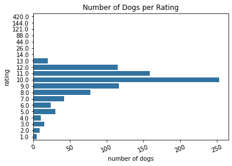

```python
base_color = sns.color_palette()[0]
val_order = master_df.rating_numerator.value_counts().sort_index(ascending=False).index
sns.countplot(data = master_df, y='rating_numerator', color=base_color, order=val_order)
plt.xticks(rotation = 22.5)
plt.xlabel("number of dogs")
plt.ylabel("rating")
plt.title("Number of Dogs per Rating");
```

I can see from the above that there are indeed very few dogs with a rating of 14 (in face there is only 1 dog with a rating of 14. By and large, most of the dogs from this dataset have ratings between 8 and 12. Another way to visualize this is with a pie chart.

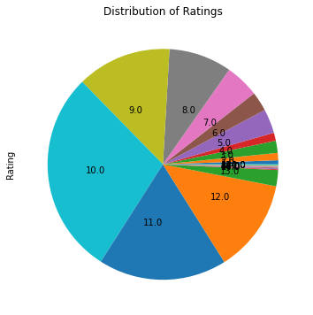

```python
plt.subplots(figsize=(12,6))
ax = master_df.rating_numerator.value_counts(normalize=True).sort_index().plot(kind='pie', labeldistance=0.5);
ax.set_title("Distribution of Ratings")
ax.set_ylabel('Rating')
plt.show();
```

I'd like to take a look at the distribution of dogs by rating by creating categories of rating to see if this allows for a more direct summary and graphic. The categories are:

> Low: less than 8  
> High: between 8 and 12  
> Highest: greater than 12

```python
# create new column rating
master_df.loc[master_df['rating_numerator'] < 8, 'rating'] = 'low'
master_df.loc[(master_df['rating_numerator'] >= 8) & (master_df['rating_numerator'] < 13), 'rating'] = 'high'
master_df.loc[master_df['rating_numerator'] >= 13, 'rating'] = 'highest'
```

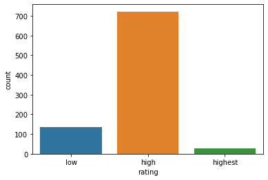

```python
# visualize bar chart by rating
order = ['low', 'high', 'highest']
sns.countplot(x = 'rating', data = master_df, order=order);
```

```python
# value counts as percentage by rating group
master_df.rating.value_counts(normalize=True).mul(100).round(1).astype(str) + '%'
```

```
high       81.7%
low        15.3%
highest     3.1%
Name: rating, dtype: object
```

We see from the above graphic and summary that 81.7% are dogs in the dataset have ratings between 8 and 12. This makes sense, as the dataset consists of dogs with retweets and favorites, of which dogs with strong ratings should be the most represented.

Now let's take a look at the average retweet and favorite count by rating sub-group:

```python
master_df.groupby('rating')['retweet_count'].describe()
```

| rating | count | mean | std | min | 25% | 50% | 75% | max |
| --- | --- | --- | --- | --- | --- | --- | --- | --- |
| high | 722.0 | 894.940443 | 2055.495992 | 11.0 | 221.25 | 468.0 | 855.0 | 28874.0 |
| highest | 27.0 | 3317.518519 | 4406.739876 | 104.0 | 743.00 | 1145.0 | 4310.5 | 14997.0 |
| low | 135.0 | 867.222222 | 1470.693930 | 30.0 | 283.00 | 532.0 | 890.0 | 15016.0 |

Highest rated dogs have the highest average retweets, but the dogs with the most retweets are in the high rating group between 8 and 12.

```python
master_df.groupby('rating')['favorite_count'].describe()
```

| rating | count | mean | std | min | 25% | 50% | 75% | max |
| --- | --- | --- | --- | --- | --- | --- | --- | --- |
| high | 722.0 | 2381.775623 | 4949.239386 | 66.0 | 695.5 | 1469.0 | 2482.25 | 74178.0 |
| highest | 27.0 | 8057.962963 | 10000.200461 | 504.0 | 2097.0 | 3105.0 | 8931.00 | 33484.0 |
| low | 135.0 | 2032.014815 | 3377.535700 | 89.0 | 615.5 | 1243.0 | 2236.50 | 34121.0 |

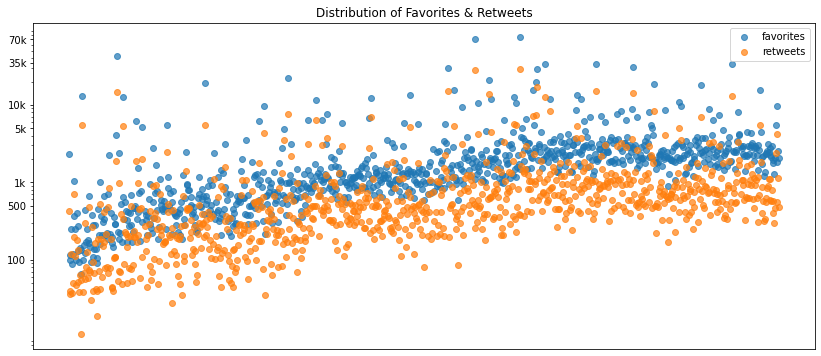

```python
plt.figure(figsize=[14,6])
plt.scatter(master_df.index, master_df.favorite_count, alpha=0.7)
plt.scatter(master_df.index, master_df.retweet_count, alpha=0.7)
plt.yscale('log')
plt.yticks([100, 500, 1e3, 5e3, 10e3, 35e3, 70e3],[100, 500, '1k', '5k', '10k', '35k', '70k']);
plt.tick_params(bottom=False, labelbottom=False)
labels = ['favorites', 'retweets']
plt.legend(labels)
plt.title('Distribution of Favorites & Retweets');
```

It looks like most dogs have higher favorites than retweets. Do any have higher retweets than favorites?

```python
master_df[master_df.retweet_count > master_df.favorite_count]['tweet_id'].count()
```

```
0
```

Let's take a look at the linear correlation between retweets and favorites:

```python
corr = np.corrcoef(master_df.retweet_count, master_df.favorite_count)
print("Pearson R correlation coefficient:", corr[0,1])
```

```
Pearson R correlation coefficient: 0.9812613590010525
```

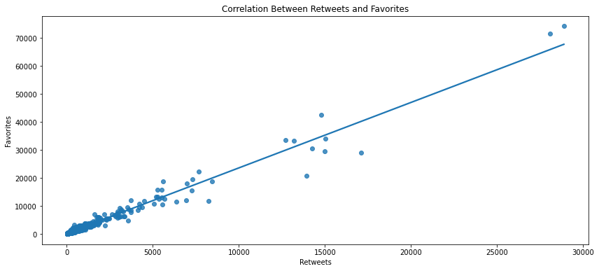

```python
plt.figure(figsize=[14,6])
sns.regplot(data = master_df, x= 'retweet_count', y= 'favorite_count', ci=None)
plt.xlabel('Retweets')
plt.ylabel('Favorites')
plt.title('Correlation Between Retweets and Favorites');
```

Which dog has the most retweets and which dog has the most favorites?

```
The most retweeted dog!
Retweets: 28874
Favorites: 74178
Rating: 12
```

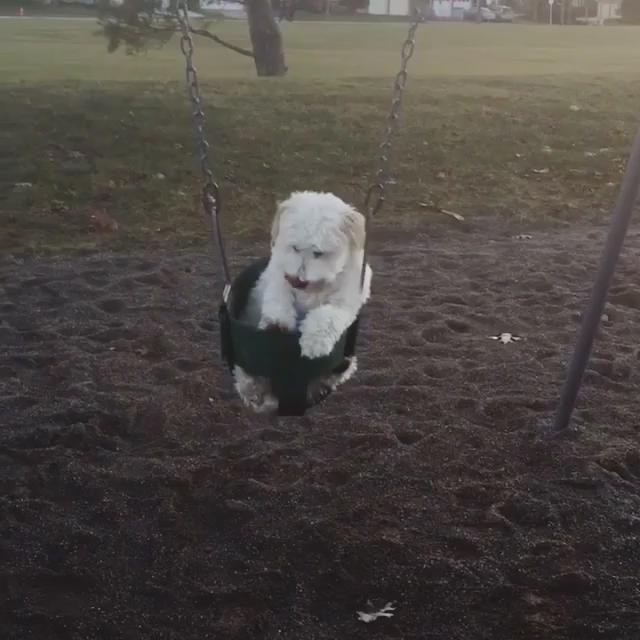

```python
# select the information for the most retweeted dog
top_rt = master_df[master_df['retweet_count'] == master_df.retweet_count.max()]
rt_rating = int(top_rt['rating_numerator'])
rt_rtcount = int(top_rt['retweet_count'])
rt_favcount = int(top_rt['favorite_count'])
url = top_rt['jpg_url'].astype(str).values[0]

print("The most retweeted dog!")
print("Retweets:", rt_rtcount)
print("Favorites:", rt_favcount)
print("Rating:", rt_rating)
Image.open(urlopen(url))
```

```
The most favorited dog!
Favorites: 74178
Retweets: 28874
Rating: 12
```

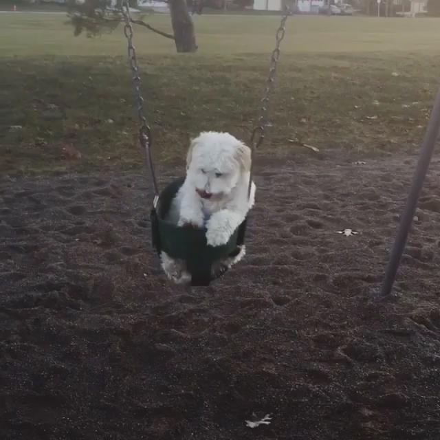

```python
# select the information for the most favorited dog
top_fav = master_df[master_df['favorite_count'] == master_df.favorite_count.max()]
fav_rating = int(top_fav['rating_numerator'])
fav_rtcount = int(top_fav['retweet_count'])
fav_favcount = int(top_fav['favorite_count'])
url = top_fav['jpg_url'].astype(str).values[0]

print("The most favorited dog!")
print("Favorites:", fav_favcount)
print("Retweets:", fav_rtcount)
print("Rating:", fav_rating)
Image.open(urlopen(url))
```

The same dog has the most retweets and favorites!

### Insights:

1. 81.7% of dogs that get retweets are rated between 8 and 12
2. All dogs have more favorites than retweets - there is a strong positive correlation between retweets and favorites
3. The same dog has the most retweets and favorites

### Visualization

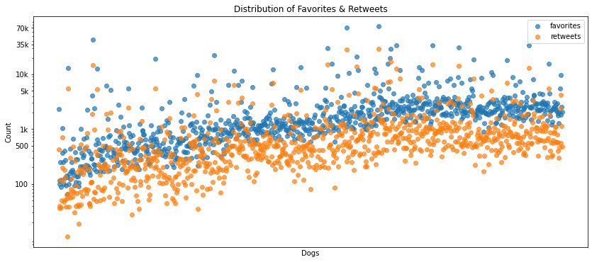

```python
plt.figure(figsize=[14,6])
plt.scatter(master_df.index, master_df.favorite_count, alpha=0.7)
plt.scatter(master_df.index, master_df.retweet_count, alpha=0.7)
plt.yscale('log')
plt.yticks([100, 500, 1e3, 5e3, 10e3, 35e3, 70e3],[100, 500, '1k', '5k', '10k', '35k', '70k']);
plt.tick_params(bottom=False, labelbottom=False)
plt.xlabel('Dogs')
plt.ylabel('Count')
labels = ['favorites', 'retweets']
plt.legend(labels)
plt.title('Distribution of Favorites & Retweets');
```

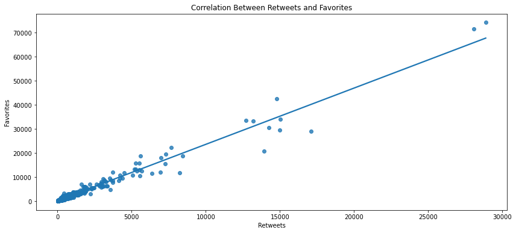

```python
plt.figure(figsize=[14,6])
sns.regplot(data = master_df, x= 'retweet_count', y= 'favorite_count', ci=None)
plt.xlabel('Retweets')
plt.ylabel('Favorites')
plt.title('Correlation Between Retweets and Favorites');
```